# Machine Learning Course Project

Anne Suchel

5 décembre 2017

## Executive Summary

In this project, we will analyse data from accelerometers on the belt, forearm, arm, and dumbell of 6 participants. The data for this project come from : http://web.archive.org/web/20161224072740/http:/groupware.les.inf.puc-rio.br/har

The goal of the project is to predict the manner in which the participant did the exercice. This is the “classe” variable in the training set.

The first step will be to the select the variables that would be usefull predictors and then do some preprocessing. The second step will be fitting several model on a training set : random forest, boosting and linear discriminant analysis. The final step will be choosing the more accurate model according to the accuracy of each model on a cross validation data set.

## Data

We will need the folowing library :

```r
library(ggplot2)
library(caret)
library(dplyr)
```

The data is avalaible on the website of the group of research and developpement of groupware technologies. The data can be downloaded here : https://d396qusza40orc.cloudfront.net/predmachlearn/pml-training.csv.

We create a training set and a cross validation set which will allow us to choose the best model.

```r
training=read.csv("pml-training.csv",na.strings=c('NA','#DIV/0!',''))

testing=read.csv("pml-testing.csv",na.strings=c('NA','#DIV/0!',''))

inTrain <- createDataPartition(y=training$classe,p=0.80,list=FALSE)
traind <- training[inTrain,]
crossvd <- training[-inTrain,]

traind$classe <- as.factor(traind$classe)
crossvd$classe <- as.factor(crossvd$classe)
```

Let’s have a look at the distribution of the different classes :

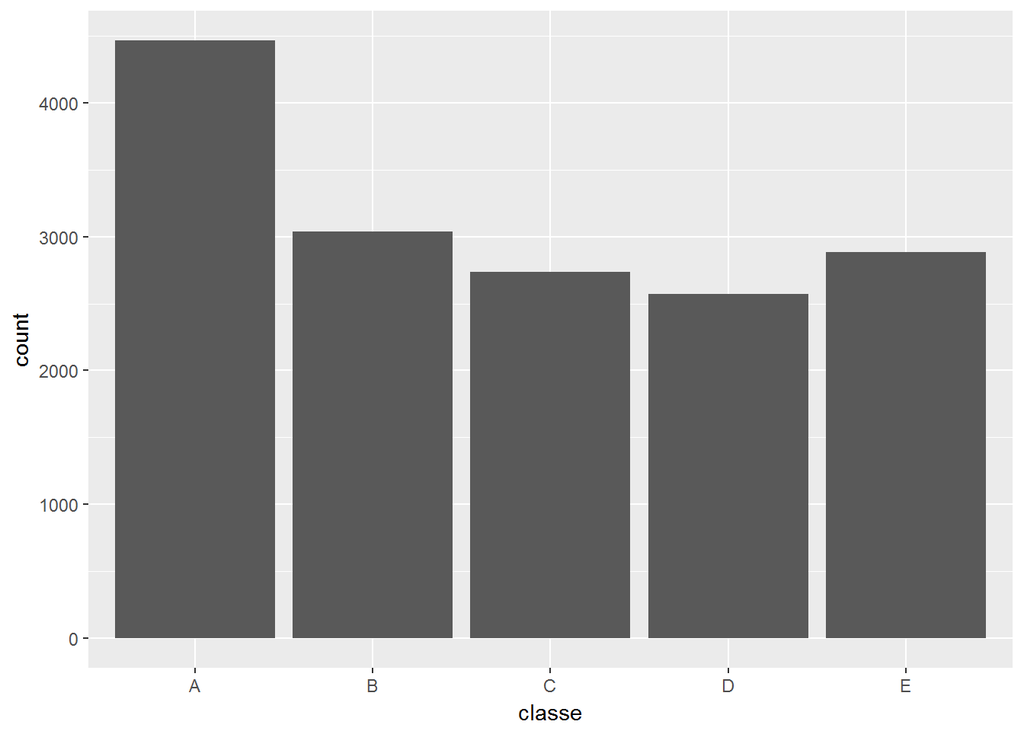

```r
qplot(classe,data=traind)
```

## Prepocessing

The overview of the data set make us notice that the 7 first variables might not be very usefull as predictors. What’s more we choose to center and scale the data (in order to prevent issue comming from predictors that are skewded) and to perform a Principal Components Analysis. Indeed, there is a lot of predictors and a weighted combinaison of predictors might be better. It will also reduce the noise.

```r
traind2 <- select(traind,-c(X,user_name,raw_timestamp_part_1,raw_timestamp_part_2,cvtd_timestamp,new_window,num_window,amplitude_yaw_forearm,skewness_yaw_forearm,kurtosis_yaw_forearm,amplitude_yaw_dumbbell,skewness_yaw_dumbbell,kurtosis_yaw_dumbbell,skewness_yaw_belt,kurtosis_yaw_belt,amplitude_yaw_belt))

which(colnames(traind2) == "classe")
```

```
## [1] 144
```

```r
preProc1 <- preProcess(traind2[,-144],method=c("center","scale"))
traind3 <- predict(preProc1,traind2)

traind3[is.na(traind3)] <- 0

preProc2 <- preProcess(traind3,method="pca")
preProc2
```

```
## Created from 15699 samples and 144 variables
##
## Pre-processing:
##   - centered (143)
##   - ignored (1)
##   - principal component signal extraction (143)
##   - scaled (143)
##
## PCA needed 59 components to capture 95 percent of the variance
```

```r
traind4 <- predict(preProc2,traind3)
```

We then have to perform the same preprocessing on the cross validation data set.

```r
crossvd2 <- select(crossvd,-c(X,user_name,raw_timestamp_part_1,raw_timestamp_part_2,cvtd_timestamp,new_window,num_window,amplitude_yaw_forearm,skewness_yaw_forearm,kurtosis_yaw_forearm,amplitude_yaw_dumbbell,skewness_yaw_dumbbell,kurtosis_yaw_dumbbell,skewness_yaw_belt,kurtosis_yaw_belt,amplitude_yaw_belt))

crossvd3 <- predict(preProc1,crossvd2)

crossvd3[is.na(crossvd3)] <- 0

crossvd4 <- predict(preProc2,crossvd3)
```

## Model Fitting

### Random Forest

```r
modRF <- train(classe ~ .,
                data = traind4,
                method = 'rf',
                trControl = trainControl(method = "cv",
                                         number = 4,
                                         allowParallel = TRUE,
                                         verboseIter = TRUE))
predRF <- predict(modRF,newdata=crossvd4)
cmRF <- confusionMatrix(predRF,crossvd2$classe)
```

### Boosting

```r
modGBM <- train(classe ~.,
                data=traind4,
                method="gbm",
                trControl = trainControl(method = "cv",
                                         number = 4,
                                         allowParallel = TRUE,
                                         verboseIter = TRUE))

predGBM <- predict(modGBM,newdata=crossvd4)
cmGBM <- confusionMatrix(predGBM,crossvd4$classe)
```

### Linear Discriminant Analysis

```r
modLDA <- train(classe ~.,
                data=traind4,
                method="lda",
                trControl = trainControl(method = "cv",
                                         number = 4,
                                         allowParallel = TRUE,
                                         verboseIter = TRUE))

predLDA <- predict(modLDA,newdata=crossvd4)
cmLDA <- confusionMatrix(predLDA,crossvd4$classe)
```

## Final Choice

We will choose the model which have the highest Accuracy.

```r
cmRF
```

```
## Confusion Matrix and Statistics
##
##           Reference
## Prediction    A    B    C    D    E
##          A 1102   11    6    2    0
##          B    3  729   13    2    4
##          C    3    9  653   21    7
##          D    0    0    5  613    4
##          E    8   10    7    5  706
##
## Overall Statistics
##
##                Accuracy : 0.9694
##                  95% CI : (0.9635, 0.9746)
##     No Information Rate : 0.2845
##     P-Value [Acc > NIR] : < 2.2e-16
##
##                   Kappa : 0.9613
##  Mcnemar's Test P-Value : 0.0006265
##
## Statistics by Class:
##
##                      Class: A Class: B Class: C Class: D Class: E
## Sensitivity            0.9875   0.9605   0.9547   0.9533   0.9792
## Specificity            0.9932   0.9930   0.9877   0.9973   0.9906
## Pos Pred Value         0.9831   0.9707   0.9423   0.9855   0.9592
## Neg Pred Value         0.9950   0.9905   0.9904   0.9909   0.9953
## Prevalence             0.2845   0.1935   0.1744   0.1639   0.1838
## Detection Rate         0.2809   0.1858   0.1665   0.1563   0.1800
## Detection Prevalence   0.2858   0.1914   0.1767   0.1586   0.1876
## Balanced Accuracy      0.9903   0.9768   0.9712   0.9753   0.9849
```

```r
cmGBM
```

```
## Confusion Matrix and Statistics
##
##           Reference
## Prediction    A    B    C    D    E
##          A 1019   78   36   17   16
##          B   19  586   53   13   51
##          C   24   60  573   85   59
##          D   44   16   18  513   27
##          E   10   19    4   15  568
##
## Overall Statistics
##
##                Accuracy : 0.8307
##                  95% CI : (0.8186, 0.8424)
##     No Information Rate : 0.2845
##     P-Value [Acc > NIR] : < 2.2e-16
##
##                   Kappa : 0.7856
##  Mcnemar's Test P-Value : < 2.2e-16
##
## Statistics by Class:
##
##                      Class: A Class: B Class: C Class: D Class: E
## Sensitivity            0.9131   0.7721   0.8377   0.7978   0.7878
## Specificity            0.9476   0.9570   0.9296   0.9680   0.9850
## Pos Pred Value         0.8739   0.8116   0.7154   0.8301   0.9221
## Neg Pred Value         0.9648   0.9460   0.9644   0.9607   0.9537
## Prevalence             0.2845   0.1935   0.1744   0.1639   0.1838
## Detection Rate         0.2598   0.1494   0.1461   0.1308   0.1448
## Detection Prevalence   0.2972   0.1840   0.2042   0.1575   0.1570
## Balanced Accuracy      0.9304   0.8645   0.8837   0.8829   0.8864
```

```r
cmLDA
```

```
## Confusion Matrix and Statistics
##
##           Reference
## Prediction   A   B   C   D   E
##          A 744 158 219  66  88
##          B  96 311  62 125 121
##          C 113 148 329  98 100
##          D 149 107  46 305  80
##          E  14  35  28  49 332
##
## Overall Statistics
##
##                Accuracy : 0.5152
##                  95% CI : (0.4994, 0.5309)
##     No Information Rate : 0.2845
##     P-Value [Acc > NIR] : < 2.2e-16
##
##                   Kappa : 0.384
##  Mcnemar's Test P-Value : < 2.2e-16
##
## Statistics by Class:
##
##                      Class: A Class: B Class: C Class: D Class: E
## Sensitivity            0.6667  0.40975  0.48099  0.47434  0.46047
## Specificity            0.8108  0.87231  0.85829  0.88354  0.96065
## Pos Pred Value         0.5835  0.43497  0.41751  0.44396  0.72489
## Neg Pred Value         0.8595  0.86035  0.88676  0.89555  0.88773
## Prevalence             0.2845  0.19347  0.17436  0.16391  0.18379
## Detection Rate         0.1897  0.07928  0.08386  0.07775  0.08463
## Detection Prevalence   0.3250  0.18226  0.20087  0.17512  0.11675
## Balanced Accuracy      0.7387  0.64103  0.66964  0.67894  0.71056
```

It is the Random Forest that gives the highest accuracy of 97% so we keep this model and we will apply it on the test dataset.